# DESeq2 comparison

Chun-Hui Gao

2018-11-01

运行下列命令可以得到本文中的结果 `example(results)`

参考资料: https://rpubs.com/ge600/deseq2

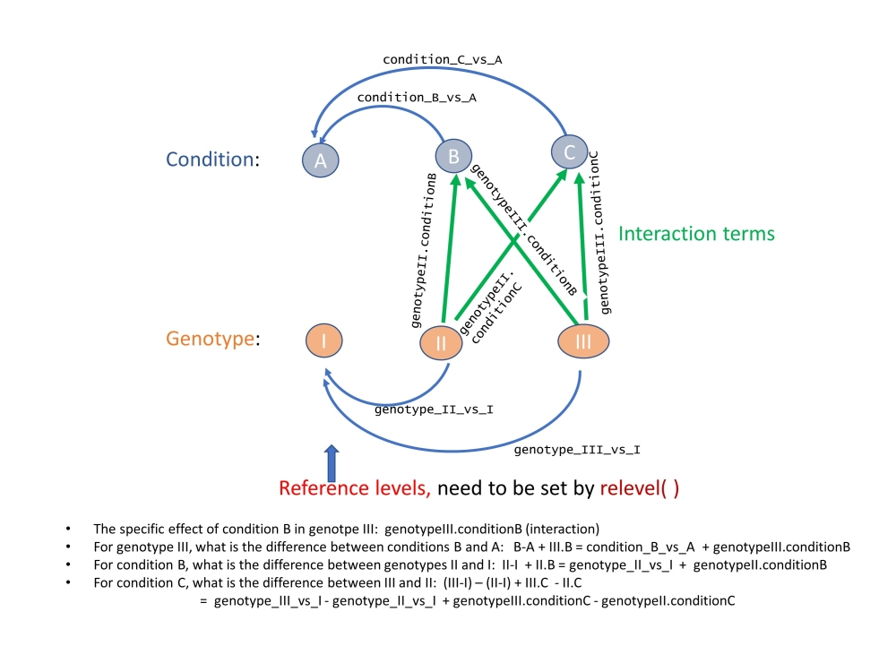

```r
library(DESeq2)
library(knitr)
```

An important point I want to make is the interpretation of results is tricky when the study design involve multiple factors. See figure above for an example involving 3 genotypes under 3 conditions. Similar to regression analysis in R, the reference levels for categorical factors forms the foundation of our intereptation. Yet, by default, they are determined alphabetically. Before runing DESeq2, it is essential to choose appropriate reference levels for each factors. This can be done by the relevel( ) function in R. Reference level is the baseline level of a factor that forms the basis of meaningful comparisons. In a wildtype vs. mutant experiment, “wild-type” is the reference level. In treated vs. untreated, the reference level is obviously untreated. More details in Exmple 3.

```r
# 设置 knitr 报告的根目录
root.dir <- "H:/Spring_Work/35. Data Analysis/community_assemble"
knitr::opts_knit$set(root.dir = root.dir, base.dir = "R")
knitr::opts_chunk$set(fig.width = 6,fig.asp=0.618,message=F,warning = F)
```

```r
setwd(root.dir)
```

## Example 1: two-group comparison

### 最简单的情况

生成一个含有 1000 个基因, 4 个样品的数据集.

```r
dds <- makeExampleDESeqDataSet(m=4)
dim(dds)  # 样本数量
```

```
## [1] 1000    4
```

样品名字是 sample1, sample2, sample3, sample4 . 它们分属 2 个 `condition`, 每个 `condition` 两个重复.

```r
colnames(dds)
```

```
## [1] "sample1" "sample2" "sample3" "sample4"
```

```r
design(dds)
```

```
## ~condition
```

```r
colData(dds)
```

```
## DataFrame with 4 rows and 1 column
##         condition
##          <factor>
## sample1         A
## sample2         A
## sample3         B
## sample4         B
```

### 差异表达分析

`results()` 中的 `contrast` 有 3 种不同的标示形式.

- 三元素的字符向量: 第一个是因子, 第二个是分子, 第三个是分母;
- 含 **两个(或一个)** 字符向量的列表: 比较时, 第一个字符向量中是分子, 第二个是分母; 如果只有一个字符向量, 那第二个会自动设为一个 **空** 字符向量.
- 一个数字比较向量

下面的命令提取 “conditionB” 相对于 “conditionA” 的表达变化情况.

```r
dds <- DESeq(dds)
resultsNames(dds)
```

```
## [1] "Intercept"        "condition_B_vs_A"
```

不加任何参数可以得到结果

```r
results(dds)
```

```
## log2 fold change (MLE): condition B vs A
## Wald test p-value: condition B vs A
## DataFrame with 1000 rows and 6 columns
##                  baseMean     log2FoldChange             lfcSE
##                 <numeric>          <numeric>         <numeric>
## gene1     2.7019620516951  0.822677442891734  2.69238890646889
## gene2    515.346304866264   1.04169260508241 0.371539065711989
## gene3    17.4720014875182  -1.38470947686728  1.13656894521274
## gene4    102.670803904517 -0.223201626491681 0.536102502990891
## gene5    20.6775927687798  0.099599412276757 0.940853352491271
## ...                   ...                ...               ...
## gene996  7.55392576822148 -0.467501179594189  1.49741256991062
## gene997  8.02022041506517   1.63936029648087  1.47877842454209
## gene998  87.1890248582933  -0.25976176863262 0.572325448783002
## gene999  14.8334763873561  -1.04303306226458  1.10119749357539
## gene1000 269.149535630082  0.307974727156382 0.379230059860667
##                        stat              pvalue              padj
##                   <numeric>           <numeric>         <numeric>
## gene1     0.305556690162822   0.759942200410864 0.999919908760222
## gene2      2.80372294925755 0.00505162927274956 0.754848911860289
## gene3     -1.21832422282846   0.223100788617711 0.999919908760222
## gene4    -0.416341325113107   0.677160257049433 0.999919908760222
## gene5     0.105860718902717   0.915692860660524 0.999919908760222
## ...                     ...                 ...               ...
## gene996  -0.312205993851175    0.75488397718831 0.999919908760222
## gene997    1.10859089453412   0.267606707946857 0.999919908760222
## gene998  -0.453870728944484   0.649921872552447 0.999919908760222
## gene999   -0.94718074491619    0.34354668534875 0.999919908760222
## gene1000  0.812105262092185   0.416731234020312 0.999919908760222
```

使用 `contrast` 时, 第一种情况:

```r
results(dds, contrast=c("condition","B","A"))  # 含 3 个元素的字符向量
```

```
## log2 fold change (MLE): condition B vs A
## Wald test p-value: condition B vs A
## DataFrame with 1000 rows and 6 columns
##                  baseMean     log2FoldChange             lfcSE
##                 <numeric>          <numeric>         <numeric>
## gene1     2.7019620516951  0.822677442891734  2.69238890646889
## gene2    515.346304866264   1.04169260508241 0.371539065711989
## gene3    17.4720014875182  -1.38470947686728  1.13656894521274
## gene4    102.670803904517 -0.223201626491681 0.536102502990891
## gene5    20.6775927687798  0.099599412276757 0.940853352491271
## ...                   ...                ...               ...
## gene996  7.55392576822148 -0.467501179594189  1.49741256991062
## gene997  8.02022041506517   1.63936029648087  1.47877842454209
## gene998  87.1890248582933  -0.25976176863262 0.572325448783002
## gene999  14.8334763873561  -1.04303306226458  1.10119749357539
## gene1000 269.149535630082  0.307974727156382 0.379230059860667
##                        stat              pvalue              padj
##                   <numeric>           <numeric>         <numeric>
## gene1     0.305556690162822   0.759942200410864 0.999919908760222
## gene2      2.80372294925755 0.00505162927274956 0.754848911860289
## gene3     -1.21832422282846   0.223100788617711 0.999919908760222
## gene4    -0.416341325113107   0.677160257049433 0.999919908760222
## gene5     0.105860718902717   0.915692860660524 0.999919908760222
## ...                     ...                 ...               ...
## gene996  -0.312205993851175    0.75488397718831 0.999919908760222
## gene997    1.10859089453412   0.267606707946857 0.999919908760222
## gene998  -0.453870728944484   0.649921872552447 0.999919908760222
## gene999   -0.94718074491619    0.34354668534875 0.999919908760222
## gene1000  0.812105262092185   0.416731234020312 0.999919908760222
```

第二种情况(第一行命令的实际效果等同与第二行):

```r
results(dds, contrast = list(c("condition_B_vs_A")))
```

```
## log2 fold change (MLE): condition_B_vs_A effect
## Wald test p-value: condition_B_vs_A effect
## DataFrame with 1000 rows and 6 columns
##                  baseMean     log2FoldChange             lfcSE
##                 <numeric>          <numeric>         <numeric>
## gene1     2.7019620516951  0.822677442891734  2.69238890646889
## gene2    515.346304866264   1.04169260508241 0.371539065711989
## gene3    17.4720014875182  -1.38470947686728  1.13656894521274
## gene4    102.670803904517 -0.223201626491681 0.536102502990891
## gene5    20.6775927687798  0.099599412276757 0.940853352491271
## ...                   ...                ...               ...
## gene996  7.55392576822148 -0.467501179594189  1.49741256991062
## gene997  8.02022041506517   1.63936029648087  1.47877842454209
## gene998  87.1890248582933  -0.25976176863262 0.572325448783002
## gene999  14.8334763873561  -1.04303306226458  1.10119749357539
## gene1000 269.149535630082  0.307974727156382 0.379230059860667
##                        stat              pvalue              padj
##                   <numeric>           <numeric>         <numeric>
## gene1     0.305556690162822   0.759942200410864 0.999919908760222
## gene2      2.80372294925755 0.00505162927274956 0.754848911860289
## gene3     -1.21832422282846   0.223100788617711 0.999919908760222
## gene4    -0.416341325113107   0.677160257049433 0.999919908760222
## gene5     0.105860718902717   0.915692860660524 0.999919908760222
## ...                     ...                 ...               ...
## gene996  -0.312205993851175    0.75488397718831 0.999919908760222
## gene997    1.10859089453412   0.267606707946857 0.999919908760222
## gene998  -0.453870728944484   0.649921872552447 0.999919908760222
## gene999   -0.94718074491619    0.34354668534875 0.999919908760222
## gene1000  0.812105262092185   0.416731234020313 0.999919908760222
```

```r
results(dds, contrast = list(c("condition_B_vs_A"),character()))
```

```
## log2 fold change (MLE): condition_B_vs_A effect
## Wald test p-value: condition_B_vs_A effect
## DataFrame with 1000 rows and 6 columns
##                  baseMean     log2FoldChange             lfcSE
##                 <numeric>          <numeric>         <numeric>
## gene1     2.7019620516951  0.822677442891734  2.69238890646889
## gene2    515.346304866264   1.04169260508241 0.371539065711989
## gene3    17.4720014875182  -1.38470947686728  1.13656894521274
## gene4    102.670803904517 -0.223201626491681 0.536102502990891
## gene5    20.6775927687798  0.099599412276757 0.940853352491271
## ...                   ...                ...               ...
## gene996  7.55392576822148 -0.467501179594189  1.49741256991062
## gene997  8.02022041506517   1.63936029648087  1.47877842454209
## gene998  87.1890248582933  -0.25976176863262 0.572325448783002
## gene999  14.8334763873561  -1.04303306226458  1.10119749357539
## gene1000 269.149535630082  0.307974727156382 0.379230059860667
##                        stat              pvalue              padj
##                   <numeric>           <numeric>         <numeric>
## gene1     0.305556690162822   0.759942200410864 0.999919908760222
## gene2      2.80372294925755 0.00505162927274956 0.754848911860289
## gene3     -1.21832422282846   0.223100788617711 0.999919908760222
## gene4    -0.416341325113107   0.677160257049433 0.999919908760222
## gene5     0.105860718902717   0.915692860660524 0.999919908760222
## ...                     ...                 ...               ...
## gene996  -0.312205993851175    0.75488397718831 0.999919908760222
## gene997    1.10859089453412   0.267606707946857 0.999919908760222
## gene998  -0.453870728944484   0.649921872552447 0.999919908760222
## gene999   -0.94718074491619    0.34354668534875 0.999919908760222
## gene1000  0.812105262092185   0.416731234020313 0.999919908760222
```

下面的命令运行不成功.

```r
results(dds, contrast = c(2))
```

with more than two groups, the call would look similar, e.g.: results(dds, contrast=c(“condition”,“C”,“A”)) etc.  
## Example 2: two conditions, two genotypes, with an interaction term

```r
dds <- makeExampleDESeqDataSet(n=100,m=12)
dds$genotype <- factor(rep(rep(c("I","II"),each=3),2))
```

样品名字是 sample1, sample2, sample3, sample4, sample5, sample6, sample7, sample8, sample9, sample10, sample11, sample12 . 它们分属 2 种基因型(“genotype”), 2 个处理(“condition”), 设 3 个重复, 共 12 个样品.

```r
colnames(dds)
```

```
##  [1] "sample1"  "sample2"  "sample3"  "sample4"  "sample5"  "sample6"
##  [7] "sample7"  "sample8"  "sample9"  "sample10" "sample11" "sample12"
```

```r
design(dds)
```

```
## ~condition
```

```r
colData(dds)
```

```
## DataFrame with 12 rows and 2 columns
##          condition genotype
##           <factor> <factor>
## sample1          A        I
## sample2          A        I
## sample3          A        I
## sample4          A       II
## sample5          A       II
## ...            ...      ...
## sample8          B        I
## sample9          B        I
## sample10         B       II
## sample11         B       II
## sample12         B       II
```

```r
design(dds) <- ~ genotype + condition + genotype:condition
dds <- DESeq(dds)
resultsNames(dds)
```

```
## [1] "Intercept"             "genotype_II_vs_I"      "condition_B_vs_A"
## [4] "genotypeII.conditionB"
```

```r
# Note: design with interactions terms by default have betaPrior=FALSE

# the condition effect for genotype I (the main effect)
results(dds, contrast=c("condition","B","A"))
```

```
## log2 fold change (MLE): condition B vs A
## Wald test p-value: condition B vs A
## DataFrame with 100 rows and 6 columns
##                  baseMean     log2FoldChange             lfcSE
##                 <numeric>          <numeric>         <numeric>
## gene1     13.275297763821  0.821913126265915 0.790199819453322
## gene2    12.1088749791069 -0.718607806690228 0.773887381934221
## gene3   0.900679647621608  -2.69698646379422   2.5236883789173
## gene4       7.28964159888  0.603569745644679  1.00004515958407
## gene5    19.1839336226062  0.418090863569974 0.715685865724225
## ...                   ...                ...               ...
## gene96   28.3534053684155 -0.696154697465568 0.597379633622562
## gene97  0.969704801147201 -0.965032427883478  2.43300160270117
## gene98    124.04857284215  0.255928679453781 0.372825294346826
## gene99   29.9387175059495  0.221439524420283 0.631145810058799
## gene100  9.85167561245015  -1.13473714949926 0.872499581961568
##                       stat            pvalue              padj
##                  <numeric>         <numeric>         <numeric>
## gene1     1.04013327519428  0.29827798609624 0.764815348964717
## gene2   -0.928568966836196 0.353112510791398  0.82119188556139
## gene3    -1.06866857506047 0.285219036448245 0.764815348964717
## gene4    0.603542489916864  0.54614785809015 0.921775528821091
## gene5    0.584182088250262 0.559097811070497 0.921775528821091
## ...                    ...               ...               ...
## gene96   -1.16534722358046 0.243878471019183 0.706017830372151
## gene97  -0.396642742368964 0.691630928686078 0.938351199916968
## gene98   0.686457392603034 0.492424723563685 0.911897636229046
## gene99   0.350853195713449 0.725698486409653 0.938351199916968
## gene100  -1.30055896066807 0.193409462163402 0.666929179873801
```

```r
# the condition effect for genotype II
# this is, by definition, the main effect *plus* the interaction term
# (the extra condition effect in genotype II compared to genotype I).
results(dds, list( c("condition_B_vs_A","genotypeII.conditionB") ))
```

```
## log2 fold change (MLE): condition_B_vs_A+genotypeII.conditionB effect
## Wald test p-value: condition_B_vs_A+genotypeII.conditionB effect
## DataFrame with 100 rows and 6 columns
##                  baseMean      log2FoldChange             lfcSE
##                 <numeric>           <numeric>         <numeric>
## gene1     13.275297763821   0.526588166260437 0.790733705443083
## gene2    12.1088749791069  -0.667576701849434 0.725302606723484
## gene3   0.900679647621608  -0.169627359160016  2.58867738701474
## gene4       7.28964159888    1.00375519604282  1.00647834462441
## gene5    19.1839336226062   0.177713186297332   0.6449728312719
## ...                   ...                 ...               ...
## gene96   28.3534053684155   0.236621158958087 0.600172893931137
## gene97  0.969704801147201 0.00316567986655459   2.6107661780155
## gene98    124.04857284215  -0.645210734686493 0.371235206289697
## gene99   29.9387175059495  -0.172525693306277 0.640940299650119
## gene100  9.85167561245015   0.837120858853374 0.853409151324808
##                        stat            pvalue              padj
##                   <numeric>         <numeric>         <numeric>
## gene1     0.665948805059937 0.505443823735394 0.933968214332807
## gene2    -0.920411281665147 0.357357875361035 0.835329468854513
## gene3   -0.0655266507950727 0.947754687663725 0.977066688313118
## gene4      0.99729437936133 0.318621641151566 0.835329468854513
## gene5     0.275535925981376 0.782904528616139  0.95252640003505
## ...                     ...               ...               ...
## gene96    0.394254991104675 0.693392789574189  0.95252640003505
## gene97  0.00121254821408821 0.999032526737825 0.999032526737825
## gene98    -1.73801062979732 0.082208940780832 0.742612898456483
## gene99   -0.269175917632979 0.787794311502049  0.95252640003505
## gene100   0.980913853049092 0.326635225441863 0.835329468854513
```

```r
# the interaction term, answering: is the condition effect *different* across genotypes?
results(dds, name="genotypeII.conditionB")
```

```
## log2 fold change (MLE): genotypeII.conditionB
## Wald test p-value: genotypeII.conditionB
## DataFrame with 100 rows and 6 columns
##                  baseMean     log2FoldChange             lfcSE
##                 <numeric>          <numeric>         <numeric>
## gene1     13.275297763821 -0.295324960005478  1.11788798981914
## gene2    12.1088749791069 0.0510311048407939  1.06064320141004
## gene3   0.900679647621608   2.52735910463421  3.61525207657343
## gene4       7.28964159888  0.400185450398141  1.41883183705211
## gene5    19.1839336226062 -0.240377677272642 0.963428840601016
## ...                   ...                ...               ...
## gene96   28.3534053684155  0.932775856423656 0.846799437534251
## gene97  0.969704801147201  0.968198107750032  3.56866876042188
## gene98    124.04857284215 -0.901139414140274 0.526131336015303
## gene99   29.9387175059495  -0.39396521772656  0.89952692084439
## gene100  9.85167561245015   1.97185800835264    1.220475291039
##                       stat             pvalue              padj
##                  <numeric>          <numeric>         <numeric>
## gene1   -0.264181172617533  0.791640317941257 0.995132351150606
## gene2   0.0481133568507788  0.961625901306785 0.995132351150606
## gene3    0.699082401753203  0.484500535768254 0.932350358929755
## gene4    0.282052770418234  0.777903047220125 0.995132351150606
## gene5   -0.249502264352691  0.802972289578437 0.995132351150606
## ...                    ...                ...               ...
## gene96    1.10153102975571  0.270665607229618 0.905740835225794
## gene97   0.271305120410103  0.786156368594556 0.995132351150606
## gene98   -1.71276514522994 0.0867557548070898 0.722964623392415
## gene99  -0.437969346550233  0.661408504446284 0.995132351150606
## gene100   1.61564762746977  0.106170520269863 0.756174157130364
```

## Example 3: two conditions, three genotypes

### ~~~ Using interaction terms ~~~

```r
dds <- makeExampleDESeqDataSet(n=100,m=18)
dds$genotype <- factor(rep(rep(c("I","II","III"),each=3),2))
```

```r
colnames(dds)
```

```
##  [1] "sample1"  "sample2"  "sample3"  "sample4"  "sample5"  "sample6"
##  [7] "sample7"  "sample8"  "sample9"  "sample10" "sample11" "sample12"
## [13] "sample13" "sample14" "sample15" "sample16" "sample17" "sample18"
```

```r
design(dds)
```

```
## ~condition
```

```r
colData(dds)
```

```
## DataFrame with 18 rows and 2 columns
##          condition genotype
##           <factor> <factor>
## sample1          A        I
## sample2          A        I
## sample3          A        I
## sample4          A       II
## sample5          A       II
## ...            ...      ...
## sample14         B       II
## sample15         B       II
## sample16         B      III
## sample17         B      III
## sample18         B      III
```

```r
design(dds) <- ~ genotype + condition + genotype:condition
dds <- DESeq(dds)
resultsNames(dds)
```

```
## [1] "Intercept"              "genotype_II_vs_I"
## [3] "genotype_III_vs_I"      "condition_B_vs_A"
## [5] "genotypeII.conditionB"  "genotypeIII.conditionB"
```

```r
# the condition effect for genotype I (the main effect)
results(dds, contrast=c("condition","B","A"))
```

```
## log2 fold change (MLE): condition B vs A
## Wald test p-value: condition B vs A
## DataFrame with 100 rows and 6 columns
##                 baseMean     log2FoldChange             lfcSE
##                <numeric>          <numeric>         <numeric>
## gene1   2.99493568602268   1.05086181951546  1.35745359478392
## gene2   6.76855317403806 -0.227398616827093  1.02440394085639
## gene3   5.63488656648378  -2.58979726840886  1.12119106934418
## gene4   1.92458344296633   4.85341372494399  2.23946638926304
## gene5   15.2380140527656 -0.479444278317203 0.737999889570646
## ...                  ...                ...               ...
## gene96  141.349473783405   -0.4912416417274 0.379190561304291
## gene97  23.0873116516973 -0.519015338010102 0.579059443517552
## gene98  16.6470373083265  0.632181900210654 0.612116472051284
## gene99  619.342337840688   0.55958763505903 0.337050040554899
## gene100 12.1125539169921 -0.288601013984473 0.796409024686247
##                       stat             pvalue              padj
##                  <numeric>          <numeric>         <numeric>
## gene1    0.774141984339983  0.438846831930956 0.803021336152723
## gene2   -0.221981395968655  0.824328365918028 0.910237279471212
## gene3    -2.30986255529462 0.0208957647016657 0.803021336152723
## gene4     2.16721882865192 0.0302181723587296 0.803021336152723
## gene5   -0.649653590864538   0.51591600795262 0.816005890224691
## ...                    ...                ...               ...
## gene96   -1.29550071087658  0.195147556288775 0.803021336152723
## gene97  -0.896307527353831  0.370088539961083 0.803021336152723
## gene98    1.03278040875477  0.301706673994111 0.803021336152723
## gene99    1.66025090558588 0.0968639876806886 0.803021336152723
## gene100 -0.362377880007287  0.717069667030305 0.853654365512267
```

```r
# the condition effect for genotype III.
# this is the main effect *plus* the interaction term
# (the extra condition effect in genotype III compared to genotype I).
results(dds, contrast=list( c("condition_B_vs_A","genotypeIII.conditionB") ))
```

```
## log2 fold change (MLE): condition_B_vs_A+genotypeIII.conditionB effect
## Wald test p-value: condition_B_vs_A+genotypeIII.conditionB effect
## DataFrame with 100 rows and 6 columns
##                 baseMean    log2FoldChange             lfcSE
##                <numeric>         <numeric>         <numeric>
## gene1   2.99493568602268 -4.37179969668303  1.70312468983481
## gene2   6.76855317403806 0.178437265563186  1.00560708719039
## gene3   5.63488656648378  1.08944581821408 0.976557521681675
## gene4   1.92458344296633  1.80973413156491  2.19990713008828
## gene5   15.2380140527656  1.05295588299824 0.762119095011672
## ...                  ...               ...               ...
## gene96  141.349473783405 0.552145109867805 0.375767293467429
## gene97  23.0873116516973 -1.48506022072289 0.598334990597423
## gene98  16.6470373083265 0.141323650584846 0.641882528695036
## gene99  619.342337840688 0.122728346883747 0.335247573745491
## gene100 12.1125539169921 -2.09574981528404 0.843487472602958
##                      stat             pvalue              padj
##                 <numeric>          <numeric>         <numeric>
## gene1    -2.5669287297497 0.0102603698638282 0.326629258157102
## gene2   0.177442330942326  0.859160959542387  0.96791635821573
## gene3    1.11559820494547  0.264594160837846 0.940386061759204
## gene4    0.82264115007995  0.410712090563782 0.940386061759204
## gene5    1.38161593101419  0.167089659764641 0.940386061759204
## ...                   ...                ...               ...
## gene96   1.46938043695297  0.141729630462129 0.940386061759204
## gene97  -2.48198792325365 0.0130651703262841 0.326629258157102
## gene98   0.22017058303824  0.825738305844457  0.96791635821573
## gene99  0.366082729585744  0.714303344166921 0.952404458889228
## gene100    -2.48462470796 0.0129688074954314 0.326629258157102
```

```r
# the interaction term for condition effect in genotype III vs genotype I.
# this tests if the condition effect is different in III compared to I
results(dds, name="genotypeIII.conditionB")
```

```
## log2 fold change (MLE): genotypeIII.conditionB
## Wald test p-value: genotypeIII.conditionB
## DataFrame with 100 rows and 6 columns
##                 baseMean     log2FoldChange             lfcSE
##                <numeric>          <numeric>         <numeric>
## gene1   2.99493568602268   -5.4226615161985  2.17790940451596
## gene2   6.76855317403806  0.405835882390279  1.43549424927868
## gene3   5.63488656648378   3.67924308662294  1.48685180162332
## gene4   1.92458344296633  -3.04367959337909  3.13921467593026
## gene5   15.2380140527656   1.53240016131544   1.0608806502318
## ...                  ...                ...               ...
## gene96  141.349473783405   1.04338675159521 0.533841211507067
## gene97  23.0873116516973 -0.966044882712787 0.832654798666916
## gene98  16.6470373083265 -0.490858249625808 0.886960525721278
## gene99  619.342337840688 -0.436859288175282 0.475387843369622
## gene100 12.1125539169921  -1.80714880129957  1.16005873627777
##                       stat             pvalue              padj
##                  <numeric>          <numeric>         <numeric>
## gene1    -2.48984714651328 0.0127798044761659 0.578738481043299
## gene2    0.282715087569461  0.777395249687415 0.957991651328368
## gene3     2.47451903586221 0.0133415710658084 0.578738481043299
## gene4   -0.969567203134057  0.332262267303565  0.93316755352951
## gene5     1.44446046874417  0.148609491880422  0.93316755352951
## ...                    ...                ...               ...
## gene96    1.95448895496408 0.0506434198156416  0.93316755352951
## gene97   -1.16019854117148    0.2459679808071  0.93316755352951
## gene98  -0.553416116491363  0.579978505589283  0.93316755352951
## gene99  -0.918953427750186  0.358119932492819  0.93316755352951
## gene100  -1.55780801849576  0.119278764638218  0.93316755352951
```

```r
# the interaction term for condition effect in genotype III vs genotype II.
# this tests if the condition effect is different in III compared to II
results(dds, contrast=list("genotypeIII.conditionB", "genotypeII.conditionB"))
```

```
## log2 fold change (MLE): genotypeIII.conditionB vs genotypeII.conditionB
## Wald test p-value: genotypeIII.conditionB vs genotypeII.conditionB
## DataFrame with 100 rows and 6 columns
##                 baseMean     log2FoldChange             lfcSE
##                <numeric>          <numeric>         <numeric>
## gene1   2.99493568602268  -5.04043275221365  2.23560800675157
## gene2   6.76855317403806 -0.394058064037174  1.39616492715938
## gene3   5.63488656648378   2.10118737039854  1.47377613645905
## gene4   1.92458344296633   1.78279894766366  3.00516997454427
## gene5   15.2380140527656   1.49591493658154  1.05786755430343
## ...                  ...                ...               ...
## gene96  141.349473783405  0.586823176305683 0.533812991375244
## gene97  23.0873116516973  -2.18265714750038 0.842808210515846
## gene98  16.6470373083265  0.539415484227223 0.885740351488466
## gene99  619.342337840688  0.471744773893069 0.474804425838096
## gene100 12.1125539169921  -3.18513281365745  1.16224923132865
##                       stat              pvalue              padj
##                  <numeric>           <numeric>         <numeric>
## gene1    -2.25461383972122  0.0241575779927966 0.450142321310281
## gene2   -0.282243205205649   0.777757031437632 0.946588339699698
## gene3     1.42571678182205   0.153950110396254 0.696092990095223
## gene4     0.59324396382405   0.553017894257946 0.903402638140507
## gene5     1.41408527985958   0.157336864632622 0.696092990095223
## ...                    ...                 ...               ...
## gene96    1.09930478610847   0.271635145439538 0.768432711771998
## gene97    -2.5897435742403 0.00960474474994894 0.450142321310281
## gene98   0.608999559883151   0.542524730622095 0.903402638140507
## gene99   0.993555974252713   0.320439086898603 0.768432711771998
## gene100  -2.74049035938383  0.0061347581691826 0.450142321310281
```

```r
# Note that a likelihood ratio could be used to test if there are any
# differences in the condition effect between the three genotypes.
```

### ~~~ Using a grouping variable ~~~

```r
# This is a useful construction when users just want to compare
# specific groups which are combinations of variables.

dds$group <- factor(paste0(dds$genotype, dds$condition))
design(dds) <- ~ group
dds <- DESeq(dds)
resultsNames(dds)
```

```
## [1] "Intercept"        "group_IB_vs_IA"   "group_IIA_vs_IA"
## [4] "group_IIB_vs_IA"  "group_IIIA_vs_IA" "group_IIIB_vs_IA"
```

```r
# the condition effect for genotypeIII
results(dds, contrast=c("group", "IIIB", "IIIA"))
```

```
## log2 fold change (MLE): group IIIB vs IIIA
## Wald test p-value: group IIIB vs IIIA
## DataFrame with 100 rows and 6 columns
##                 baseMean    log2FoldChange             lfcSE
##                <numeric>         <numeric>         <numeric>
## gene1   2.99493568602268 -4.37180982526693  1.70312696613953
## gene2   6.76855317403806 0.178437515041544  1.00560786744054
## gene3   5.63488656648378  1.08944916593032 0.976558311322516
## gene4   1.92458344296633   1.8097116267803  2.19991510883249
## gene5   15.2380140527656  1.05295677557863 0.762119454254979
## ...                  ...               ...               ...
## gene96  141.349473783405 0.552145217365824 0.375767333825435
## gene97  23.0873116516973 -1.48506031619283 0.598335137251902
## gene98  16.6470373083265 0.141323474989105 0.641882728480303
## gene99  619.342337840688 0.122728228558396 0.335247602076128
## gene100 12.1125539169921 -2.09575046924529  0.84348787058486
##                      stat             pvalue              padj
##                 <numeric>          <numeric>         <numeric>
## gene1   -2.56693124598718 0.0102602954111398  0.32662966953003
## gene2   0.177442441352115  0.859160872824121   0.9679159014169
## gene3    1.11560073095371  0.264593079101101  0.94038580744608
## gene4   0.822627936648303  0.410719606899237  0.94038580744608
## gene5    1.38161645093808  0.167089500038707  0.94038580744608
## ...                   ...                ...               ...
## gene96   1.46938056521519  0.141729595692443  0.94038580744608
## gene97  -2.48198747446719 0.0130651867812012  0.32662966953003
## gene98  0.220170240946811  0.825738572257841   0.9679159014169
## gene99    0.3660823457002  0.714303630611444 0.952404840815259
## gene100 -2.48462431094846 0.0129688219569974  0.32662966953003
```